# CloudsLab2_User41

```
Training Dataset:
x:
 [ 0.72862259  1.86075805  0.88458528 ...,  0.41672376  0.73657175
 -1.1960535 ]

y:
 [ -1.00391651  52.99322439 -29.11248816 ...,  -6.8604759   19.23948011
 -20.83894735]

Theta:
 [0 1]

Parameters after Batch Gradient Descent:
 Loss =  403.018140744
Intercept =  -0.106975625253 Slope =  14.5135526584
```

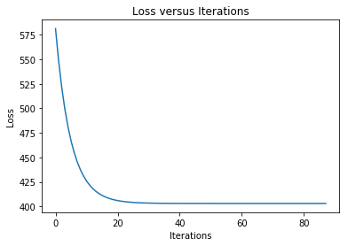

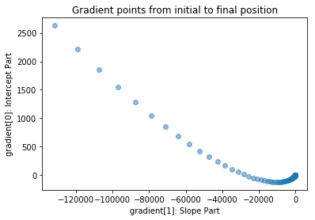

```
 Regression Line with training data
```

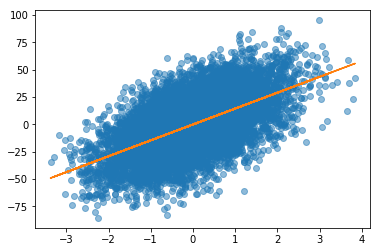

```
Gradient points from initial the position:
```

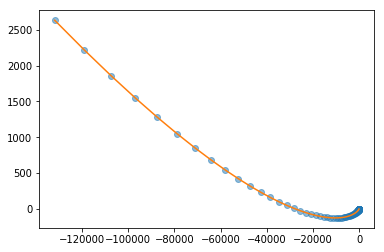

[output not shown]

```python
#Question 1: Batch Gradient Descent
get_ipython().magic('matplotlib inline')
import numpy as np
import seaborn as sns
import matplotlib.pyplot as plt
import matplotlib.animation as animation
from scipy import stats
from sklearn.datasets.samples_generator import make_regression
from mpl_toolkits import mplot3d

def gradientDescent(x,y,theta,learn_rate,max_iter):
    a = np.ones(10000)
    b = np.array(x)
    # 2-d array of (1,x) pairs
    x2d = np.column_stack((a,b))
    #print('\nx 2-d:\n',x2d)
    i = 0

    #stop criterion: difference in consecutive loss is zero (rounded to 6 decimal places)
    loss_prev = 1
    loss_val = 0

    #Lists to keep track of parameters
    loss = []
    grad_x = []
    grad_y = []
    theta_x = []
    theta_y = []

    y_pred = np.array([])
    error = np.array([])

    #stop criterion: difference in consecutive losses is zero (rounded to 6 decimal places)
    while i <= max_iter and (round(loss_prev,6) - round(loss_val,6) != 0):
        y_pred = np.dot(x2d,theta)
        error = y_pred - y

        loss_prev = loss_val
        loss_val = ((y_pred - y) ** 2).mean(axis=None)
        loss.append(loss_val)

        gradient = np.dot(x2d.T, (np.dot(x2d, theta.T) - y))

        grad_x.append(gradient[1])
        grad_y.append(gradient[0])
        theta = theta - learn_rate * gradient

        theta_x.append(theta[1])
        theta_y.append(theta[0])
        i += 1
    print('\nParameters after Batch Gradient Descent:\n Loss = ',loss_val,'\nIntercept = ',theta[0],'Slope = ',theta[1])

    plt.plot(range(len(loss)), loss)
    plt.xlabel('Iterations')
    plt.ylabel('Loss')
    plt.title('Loss versus Iterations')
    plt.show()

    plt.plot(grad_x,grad_y,'o',alpha=0.5)
    plt.xlabel('gradient[1]: Slope Part')
    plt.ylabel('gradient[0]: Intercept Part')
    plt.title('Gradient points from initial to final position')
    plt.show()

    #Question 2: Regression line along with training data
    print('\n Regression Line with training data\n')
    plt.plot(x,y,'o',alpha=0.5)
    plt.plot(x,np.dot(x2d,theta))
    plt.show()

    #Question 4: Gradient point positions line chart
    print('\nGradient points from initial the position:\n')
    plt.plot(grad_x,grad_y,'o',alpha=0.5)
    plt.plot(grad_x,grad_y)
    plt.show()

    #Question 3: 3-d plot of theta parameters and loss
    #**Erroneous result
    X, Y = np.meshgrid(np.asarray(theta_x),np.asarray(theta_y))
    c = np.ones(88)
    d = np.asarray(loss)
    Z = np.column_stack((c,d,Z))
    ax = plt.axes(projection='3d')
    ax.plot_surface(X,Y,Z) #,rstride=1, cstride=1,cmap='cubehelix', edgecolor='none')
    plt.plot(j, loss)
    plt.show()

x, y = make_regression(n_samples = 10000,
                       n_features=1,
                       n_informative=1,
                       noise=20,
                       random_state=2017)

x = x.flatten()
slope, intercept,_,_,_ = stats.linregress(x,y)
print('Training Dataset:\nx:\n',x)
print('\ny:\n',y)
theta = np.array([0,1])
print('\nTheta:\n',theta)
learn_rate = 0.00001
max_iter = 1000

gradientDescent(x,y,theta,learn_rate,max_iter)
```

```
Training Dataset:
x:
 [ 0.72862259  1.86075805  0.88458528 ...,  0.41672376  0.73657175
 -1.1960535 ]

y:
 [ -1.00391651  52.99322439 -29.11248816 ...,  -6.8604759   19.23948011
 -20.83894735]

Initial Theta:
 [0 1]

Parameters from Scikit Learn:
Intercept: -0.106823564161 Slope: 14.5151694796

Parameters from Stochastic Gradient Descent:

Loss =  403.025933181
Intercept =  -0.11173 Slope =  14.5049500001
```

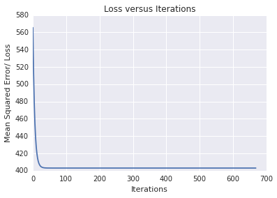

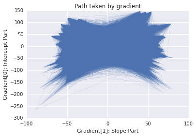

```python
#Question 5: Stochastic Gradient Descent

get_ipython().magic('matplotlib inline')
import numpy as np
import seaborn as sns
import matplotlib.pyplot as plt
import matplotlib.animation as animation
from scipy import stats
from sklearn.datasets.samples_generator import make_regression
from mpl_toolkits import mplot3d
plt.rcParams['agg.path.chunksize'] = 10000

def StochasticGD(x,y,theta,learn_rate,max_iter):
    i = 0

    a = np.ones(10000)
    b = np.array(x)
    # 2-d array of (1,x) pairs
    x2d = np.column_stack((a,b))

    #lists to keep track of parameters
    stoc_loss = []
    grad_x = []
    grad_y = []
    theta_x = []
    theta_y = []

    #stop criterion: difference in consecutive losses is zero (rounded to 6 decimal places)
    loss_prev = 1
    loss_val = 0
    gradient = np.array([0,0])

    xy = list(zip(x,y))
    #stop criterion: difference in consecutive losses is zero (rounded to 6 decimal places)
    while i <= max_iter and (round(loss_prev,6) - round(loss_val,6) != 0):

        tot_sq_error = 0
        np.random.shuffle(xy)
        #Compute parameters for each pair of (x,y)
        for x,y in xy:

            sq_error = (theta[0] + (theta[1] * x) - y) ** 2
            tot_sq_error += sq_error

            gradient[0] = theta[0] + (theta[1] * x) - y
            gradient[1] = x * gradient[0]

            grad_x.append(gradient[1])
            grad_y.append(gradient[0])
            theta = theta - learn_rate * gradient

            theta_x.append(theta[1])
            theta_y.append(theta[0])

        loss_prev = loss_val
        #Mean Square Error (Loss)
        loss_val = 0.0001 * tot_sq_error
        stoc_loss.append(loss_val)

        i += 1

    print('\nParameters from Stochastic Gradient Descent:\n')
    print('Loss = ',loss_val,'\nIntercept = ',theta[0],'Slope = ',theta[1])
    #Loss versus Iterations
    plt.plot(range(len(stoc_loss)),stoc_loss)
    plt.xlabel('Iterations')
    plt.ylabel('Mean Squared Error/ Loss')
    plt.title('Loss versus Iterations')
    plt.show()
    #Plot of path taken by gradient
    plt.plot(grad_y,grad_x,lw=0.1)
    plt.xlabel('Gradient[1]: Slope Part')
    plt.ylabel('Gradient[0]: Intercept Part')
    plt.title('Path taken by gradient')
    plt.show()


x, y = make_regression(n_samples = 10000,
                       n_features=1,
                       n_informative=1,
                       noise=20,
                       random_state=2017)

x = x.flatten()
print('Training Dataset:\nx:\n',x)
print('\ny:\n',y)
theta = np.array([0,1])
print('\nInitial Theta:\n',theta)
slope, intercept,_,_,_ = stats.linregress(x,y)
print('\nParameters from Scikit Learn:\nIntercept:',intercept,'Slope:',slope)
learn_rate = 0.00001
max_iter = 1000

StochasticGD(x,y,theta,learn_rate,max_iter)
```

```
Training Dataset:
x:
 [ 0.72862259  1.86075805  0.88458528 ...,  0.41672376  0.73657175
 -1.1960535 ]

y:
 [ -1.00391651  52.99322439 -29.11248816 ...,  -6.8604759   19.23948011
 -20.83894735]

Initial Theta:
 [0 1]

Parameters from Scikit Learn:
Intercept: -0.106823564161 Slope: 14.5151694796

Parameters calculated by gradient descent at iteration  229
Avg loss =  403.02618038 Intercept =  -0.109578860499 Slope =  14.5278589278
```

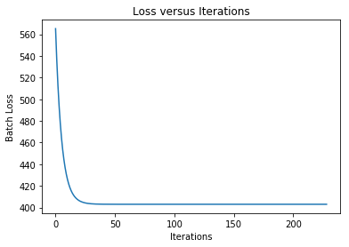

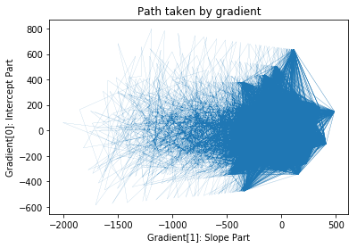

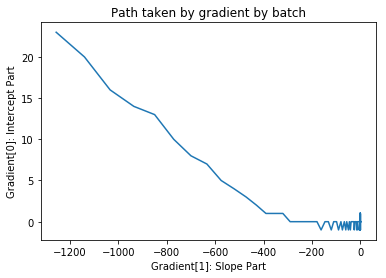

```python
#Question 6 Mini Batch Gradient Descent
get_ipython().magic('matplotlib inline')
import numpy as np
import seaborn as sns
import matplotlib.pyplot as plt
import matplotlib.animation as animation
from scipy import stats
from sklearn.datasets.samples_generator import make_regression
from mpl_toolkits import mplot3d
plt.rcParams['agg.path.chunksize'] = 10000

def ExtractMB(x,y,theta,learn_rate,max_iter):
    xy = list(zip(x,y))

    #stopping criterion: when the difference between consecutive average losses (averaged over a mini-batch) is zero
    #when rounded to 6 decimal places
    avg_loss_prev = 1
    avg_loss = 0

    #lists to keep track of parameters
    avg_loss_arr =[]
    grad_avg_x = []
    grad_avg_y = []

    #lists to hold ALL gradient positions encountered
    gX = []
    gY = []

    gradient_avg = np.array([0,0])
    theta_avg = np.array([0,0])
    list_of_batches = []
    #number of mini-batches is 100; each with 100 points [(x,y) pairs]
    num_mb = 100
    i = 0
    while i < 100:
        #slice positions
        f = i * 100
        l = f + 100
        list_of_batches.append(xy[f:l])
        i += 1
    j = 0
    #Iterating over all mini-batches:
    while j <= max_iter and (round(avg_loss_prev,6) - round(avg_loss,6) != 0):
        np.random.shuffle(list_of_batches)
        loss = []
        grad_x = []
        grad_y = []
        theta_x = []
        theta_y = []
        k = 0

        #For each mini-batch: Compute Parameters
        while k < len(list_of_batches):

            a = np.ones(100)
            x = list(zip(*list_of_batches[k]))[0]
            b = np.array(x)
            y = list(zip(*list_of_batches[k]))[1]
            x2d = np.column_stack((a,b))

            loss_val = 0


            y_pred = np.array([])
            error = np.array([])

            y_pred = np.dot(x2d,theta)
            error = y_pred - y

            loss_val = ((y_pred - y) ** 2).mean(axis=None)
            loss.append(loss_val)

            gradient = np.dot(x2d.T, (np.dot(x2d, theta.T) - y))

            grad_x.append(gradient[1])
            grad_y.append(gradient[0])
            gX.append(gradient[1])
            gY.append(gradient[0])

            theta = theta - learn_rate * gradient

            theta_x.append(theta[1])
            theta_y.append(theta[0])

            k += 1

        avg_loss_prev = avg_loss
        avg_loss = sum(loss)/ len(loss)
        avg_loss_arr.append(avg_loss)

        gradient_avg[1] = sum(grad_x)/len(grad_x)
        grad_avg_x.append(gradient_avg[1])
        #gX.append(gradient_avg[1])
        gradient_avg[0] = sum(grad_y)/len(grad_y)
        grad_avg_y.append(gradient_avg[0])
        #gY.append(gradient_avg[0])

        j += 1

    print('\nParameters calculated by gradient descent at iteration ',j)
    print('Avg loss = ',avg_loss,'Intercept = ',sum(theta_y)/100,'Slope = ',sum(theta_x)/100)


    #Plot of loss versus iterations

    plt.plot(range(len(avg_loss_arr)),avg_loss_arr)
    plt.xlabel('Iterations')
    plt.ylabel('Batch Loss')
    plt.title('Loss versus Iterations')
    plt.show()

    #Plot of path taken by gradient
    plt.plot(gX,gY,lw = 0.1)
    plt.xlabel('Gradient[1]: Slope Part')
    plt.ylabel('Gradient[0]: Intercept Part')
    plt.title('Path taken by gradient')
    plt.show()

    #Plot of path taken by gradient by batch
    plt.plot(grad_avg_x,grad_avg_y)
    plt.xlabel('Gradient[1]: Slope Part')
    plt.ylabel('Gradient[0]: Intercept Part')
    plt.title('Path taken by gradient by batch')
    plt.show()



x, y = make_regression(n_samples = 10000,
                       n_features=1,
                       n_informative=1,
                       noise=20,
                       random_state=2017)

x = x.flatten()
print('Training Dataset:\nx:\n',x)
print('\ny:\n',y)
theta = np.array([0,1])
print('\nInitial Theta:\n',theta)
slope, intercept,_,_,_ = stats.linregress(x,y)
print('\nParameters from Scikit Learn:\nIntercept:',intercept,'Slope:',slope)
learn_rate = 0.00001
max_iter = 1000

ExtractMB(x,y,theta,learn_rate,max_iter)
```

```
Training Dataset:
x:
 [ 0.72862259  1.86075805  0.88458528 ...,  0.41672376  0.73657175
 -1.1960535 ]

y:
 [ -1.00391651  52.99322439 -29.11248816 ...,  -6.8604759   19.23948011
 -20.83894735]

Initial Theta:
 [0 1]

Parameters from Scikit Learn:
Intercept: -0.106823564161 Slope: 14.5151694796
```

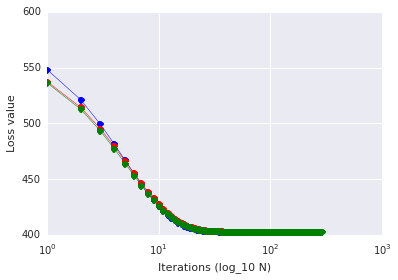

```python
#Question 7: Loss Comparison Plot
get_ipython().magic('matplotlib inline')
import numpy as np
import seaborn as sns
import matplotlib.pyplot as plt
import matplotlib.animation as animation
from scipy import stats
from sklearn.datasets.samples_generator import make_regression
from mpl_toolkits import mplot3d
plt.rcParams['agg.path.chunksize'] = 10000

def gradientDescent(x,y,theta,learn_rate,max_iter):
    a = np.ones(10000)
    b = np.array(x)
    # 2-d array of (1,x) pairs
    x2d = np.column_stack((a,b))
    #print('\nx 2-d:\n',x2d)
    i = 0

    #stop criterion: difference in consecutive loss is zero (rounded to 6 decimal places)
    loss_prev = 1
    loss_val = 0

    #Lists to keep track of parameters
    loss = []
    grad_x = []
    grad_y = []
    theta_x = []
    theta_y = []

    y_pred = np.array([])
    error = np.array([])

    #stop criterion: difference in consecutive losses is zero (rounded to 6 decimal places)
    while i <= max_iter and (round(loss_prev,6) - round(loss_val,6) != 0):
        y_pred = np.dot(x2d,theta)
        error = y_pred - y

        loss_prev = loss_val
        loss_val = ((y_pred - y) ** 2).mean(axis=None)
        loss.append(loss_val)

        gradient = np.dot(x2d.T, (np.dot(x2d, theta.T) - y))

        grad_x.append(gradient[1])
        grad_y.append(gradient[0])
        theta = theta - learn_rate * gradient

        theta_x.append(theta[1])
        theta_y.append(theta[0])
        i += 1
    #print('\nParameters after Batch Gradient Descent:\n Loss = ',loss_val)

    #plt.plot(range(len(loss)), loss)
    #plt.xlabel('Iterations')
    #plt.ylabel('Loss')
    #plt.title('Loss versus Iterations BATCH')
    #plt.show()

    return loss

#==============================================================================================================================

def StochasticGD(x,y,theta,learn_rate,max_iter):
    i = 0

    a = np.ones(10000)
    b = np.array(x)
    # 2-d array of (1,x) pairs
    x2d = np.column_stack((a,b))

    #lists to keep track of parameters
    stoc_loss = []
    grad_x = []
    grad_y = []
    theta_x = []
    theta_y = []

    #stop criterion: difference in consecutive losses is zero (rounded to 6 decimal places)
    loss_prev = 1
    loss_val = 0
    gradient = np.array([0,0])

    xy = list(zip(x,y))
    #stop criterion: difference in consecutive losses is zero (rounded to 6 decimal places)
    while i <= max_iter and (round(loss_prev,6) - round(loss_val,6) != 0):

        tot_sq_error = 0
        np.random.shuffle(xy)
        #Compute parameters for each pair of (x,y)
        for x,y in xy:

            sq_error = (theta[0] + (theta[1] * x) - y) ** 2
            tot_sq_error += sq_error

            gradient[0] = theta[0] + (theta[1] * x) - y
            gradient[1] = x * gradient[0]

            grad_x.append(gradient[1])
            grad_y.append(gradient[0])
            theta = theta - learn_rate * gradient

            theta_x.append(theta[1])
            theta_y.append(theta[0])

        loss_prev = loss_val
        #Mean Square Error (Loss)
        loss_val = 0.0001 * tot_sq_error
        stoc_loss.append(loss_val)

        i += 1

    #print('\nParameters from Stochastic Gradient Descent:\n')
    #print('Loss = ',loss_val,'\nIntercept = ',theta[0],'Slope = ',theta[1])
    #Loss versus Iterations
    #plt.plot(range(len(stoc_loss)),stoc_loss)
    #plt.xlabel('Iterations')
    #plt.ylabel('Mean Squared Error/ Loss')
    #plt.title('Loss versus Iterations STOCHASTIC')
    #plt.show()

    return stoc_loss
#==============================================================================================================================

def ExtractMB(x,y,theta,learn_rate,max_iter):
    xy = list(zip(x,y))

    #stopping criterion: when the difference between consecutive average losses (averaged over a mini-batch) is zero
    #when rounded to 6 decimal places
    avg_loss_prev = 1
    avg_loss = 0

    #lists to keep track of parameters
    avg_loss_arr =[]
    grad_avg_x = []
    grad_avg_y = []

    #lists to hold ALL gradient positions encountered
    gX = []
    gY = []

    gradient_avg = np.array([0,0])
    theta_avg = np.array([0,0])
    list_of_batches = []
    #number of mini-batches is 100; each with 100 points [(x,y) pairs]
    num_mb = 100
    i = 0
    while i < 100:
        #slice positions
        f = i * 100
        l = f + 100
        list_of_batches.append(xy[f:l])
        i += 1
    j = 0
    #Iterating over all mini-batches:
    while j <= max_iter and (round(avg_loss_prev,6) - round(avg_loss,6) != 0):
        np.random.shuffle(list_of_batches)
        loss = []
        grad_x = []
        grad_y = []
        theta_x = []
        theta_y = []
        k = 0

        #For each mini-batch: Compute Parameters
        while k < len(list_of_batches):

            a = np.ones(100)
            x = list(zip(*list_of_batches[k]))[0]
            b = np.array(x)
            y = list(zip(*list_of_batches[k]))[1]
            x2d = np.column_stack((a,b))

            loss_val = 0


            y_pred = np.array([])
            error = np.array([])

            y_pred = np.dot(x2d,theta)
            error = y_pred - y

            loss_val = ((y_pred - y) ** 2).mean(axis=None)
            loss.append(loss_val)

            gradient = np.dot(x2d.T, (np.dot(x2d, theta.T) - y))

            grad_x.append(gradient[1])
            grad_y.append(gradient[0])
            gX.append(gradient[1])
            gY.append(gradient[0])

            theta = theta - learn_rate * gradient

            theta_x.append(theta[1])
            theta_y.append(theta[0])

            k += 1

        avg_loss_prev = avg_loss
        avg_loss = sum(loss)/ len(loss)
        avg_loss_arr.append(avg_loss)

        gradient_avg[1] = sum(grad_x)/len(grad_x)
        grad_avg_x.append(gradient_avg[1])
        #gX.append(gradient_avg[1])
        gradient_avg[0] = sum(grad_y)/len(grad_y)
        grad_avg_y.append(gradient_avg[0])
        #gY.append(gradient_avg[0])

        j += 1

    #print('\nParameters calculated by Mini Batch gradient descent at iteration ',j)
    #print('Avg loss = ',avg_loss,'Intercept = ',sum(theta_y)/100,'Slope = ',sum(theta_x)/100)


    #Plot of loss versus iterations

    #plt.plot(range(len(avg_loss_arr)),avg_loss_arr)
    #plt.xlabel('Iterations')
    #plt.ylabel('Batch Loss')
    #plt.title('Loss versus Iterations MINI-BATCH')
    #plt.show()
    return avg_loss_arr

#===============================================================================================================================

x, y = make_regression(n_samples = 10000,
                       n_features=1,
                       n_informative=1,
                       noise=20,
                       random_state=2017)

x = x.flatten()
print('Training Dataset:\nx:\n',x)
print('\ny:\n',y)
theta = np.array([0,1])
print('\nInitial Theta:\n',theta)
slope, intercept,_,_,_ = stats.linregress(x,y)
print('\nParameters from Scikit Learn:\nIntercept:',intercept,'Slope:',slope)
learn_rate = 0.00001
max_iter = 1000

loss = gradientDescent(x,y,theta,learn_rate,max_iter)
stoc_loss = StochasticGD(x,y,theta,learn_rate,max_iter)
mb_loss = ExtractMB(x,y,theta,learn_rate,max_iter)

plt.figure()
plt.semilogx(range(len(loss)), loss, "b-o", lw=0.5) # Batch GD
plt.semilogx(range(len(stoc_loss)),stoc_loss, "r-o", lw=0.5) # Stochastic GD
plt.semilogx(range(len(mb_loss)),mb_loss, "g-o", lw=0.5) # Mini-batch GD
plt.xlabel("Iterations (log_10 N)")
plt.ylabel("Loss value")
plt.show()
```

```
Training Dataset:
x:
 [ 0.72862259  1.86075805  0.88458528 ...,  0.41672376  0.73657175
 -1.1960535 ]

y:
 [ -1.00391651  52.99322439 -29.11248816 ...,  -6.8604759   19.23948011
 -20.83894735]

Parameters from Scikit Learn:
Intercept: -0.106823564161 Slope: 14.5151694796

Parameters calculated by distributed Mini-Batch SGD:

Loss =  409.209211386 Intercept =  0 Slope =  12
```

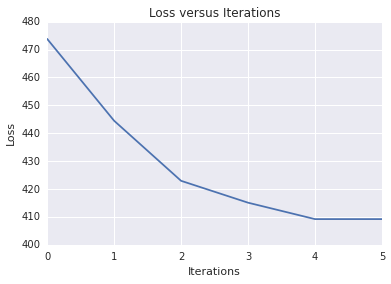

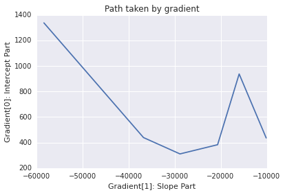

```python
#Question 8: Distributed Mini-Batch

get_ipython().magic('matplotlib inline')
import numpy as np
import seaborn as sns
import matplotlib.pyplot as plt
import matplotlib.animation as animation
import pyspark
from scipy import stats
from sklearn.datasets.samples_generator import make_regression
from mpl_toolkits import mplot3d
plt.rcParams['agg.path.chunksize'] = 10000


def distributed(x, y, learn_rate,max_iter):
    # parameters_computed = dist_xy.mapPartitions(computeParams,preservesPartitioning = True).collect()
    #Iterable function
    def computeParams(mini_batch_dataset):

        # This part executes in parallel, on each of the k worker machines
        # This is essentially the same code as for the serial implementation
        # Indeed, we're working on an embarassingly parallel formulation

        #mean_sq_error = 0

        iterator = []

        grad_x_batch = []
        grad_y_batch = []
        theta_x_batch = []
        theta_y_batch = []
        theta_batch = np.array([0,0])
        xx = []
        yy = []
        for x,y in mini_batch_dataset:
            xx.append(x)
            yy.append(y)

        a = np.ones(len(xx))
        b = np.array(xx)
        x2d = np.column_stack((a,b))
        #for x,y in mini_batch_dataset:
        gradient_batch = np.dot(x2d.T, (np.dot(x2d, theta_broadcast.value.T) - yy))
        theta_batch = theta_broadcast.value - learn_rate_b.value * gradient_batch

        grad_x_batch.append(gradient_batch[1])
        grad_y_batch.append(gradient_batch[0])
        theta_x_batch.append(theta_batch[1])
        theta_y_batch.append(theta_batch[0])

        iterator.append([[gradient_batch[0], gradient_batch[1]], [theta_batch[0], theta_batch[1]]])

        #return ([gradient_batch[0],gradient_batch[1]],[theta_batch[0],theta_batch[1]])
        return iter(iterator)


    def loss_compute(theta):
        a = np.ones(len(x))
        b = np.array(x)
        x2d = np.column_stack((a,b))
        yy = np.array(y)
        loss_val =  ((np.dot(x2d, theta) - yy) ** 2).mean(axis = None)#Mean Square Loss
        return loss_val

    xy = list(zip(x,y))
    dist_xy = sc.parallelize(xy)

    theta = np.array([0,1])
    gradient = np.array([0,0])
    loss_val = 0
    loss_prev = 1
    grad_x = []
    grad_y = []
    theta_x = []
    theta_y = []
    loss = []
    mini_batch_fraction = 1.8

    learn_rate_b = sc.broadcast(learn_rate)

    i = 0
    while i < max_iter and (round(loss_prev,6) - round(loss_val,6) != 0):

        # Initialize random paramters

        theta_broadcast = sc.broadcast(theta)
        #gradient_bc = sc.broadcast(gradient)
        #loss_bc = sc.broadcast(loss)
        #print('TEST')

        # Randomly partition the input, giving T examples to each machine.
        parameters_computed = dist_xy.sample(True,mini_batch_fraction).mapPartitions(computeParams,preservesPartitioning = True).collect()

        grad_i_sum = np.array([0,0])
        theta_i_sum = np.array([0,0])
        #loss_i_sum = 0.0

        for p in parameters_computed:
            # Here we aggregate from all machines, and compute the update for iteration i
            #print('\nComputed Grads: ',p[0][0],p[0][1],'Computed Thetas:',p[1][0],p[1][1])
            grad_i_sum[0] += p[0][0]
            grad_i_sum[1] += p[0][1]

            theta_i_sum[0] += p[1][0]
            theta_i_sum[1] += p[1][1]

            #loss_i_sum += p[1]


        # The update is simply the average of all updates coming from each of the k worker machines
        # Aggregate from all computers params = average(params_k)
        gradient[0] = float(grad_i_sum[0])/len(parameters_computed)
        gradient[1] = float(grad_i_sum[1])/len(parameters_computed)
        grad_x.append(gradient[1])
        grad_y.append(gradient[0])

        theta[0] = float(theta_i_sum[0])/float(len(parameters_computed))
        theta[1] = float(theta_i_sum[1])/float(len(parameters_computed))
        #theta[0] = theta[0] - learn_rate * gradient[0]
        #theta[1] = theta[1] - learn_rate * gradient[1]

        theta_x.append(theta[1])
        theta_y.append(theta[0])

        loss_prev = loss_val

        #loss_val = loss_i_sum
        #loss_val = loss_i_sum
        loss_val = loss_compute(theta)
        loss.append(loss_val)
        #print('\nParameters at iteration ',i,'\nLoss = ',loss_val,'Intercept = ',theta[0],'Slope = ',theta[1],'Gradients: ',gradient)
        i += 1

    return theta, loss_val, i, loss, grad_x, grad_y




x, y = make_regression(n_samples = 10000,
                       n_features=1,
                       n_informative=1,
                       noise=20,
                       random_state=2017)

x = x.flatten()
print('Training Dataset:\nx:\n',x)
print('\ny:\n',y)
slope, intercept,_,_,_ = stats.linregress(x,y)
print('\nParameters from Scikit Learn:\nIntercept:',intercept,'Slope:',slope)
learn_rate = 0.0000956
max_iter = 1000
loss = []
grad_x = []
grad_y = []
theta, loss_val, i, loss, grad_x, grad_y = distributed(x, y, learn_rate, max_iter)
print('\nParameters calculated by distributed Mini-Batch SGD:\n')
print('Loss = ',loss_val,'Intercept = ',theta[0],'Slope = ',theta[1])

#Iterations versus loss
plt.plot(range(len(loss)),loss)
plt.xlabel('Iterations')
plt.ylabel('Loss')
plt.title('Loss versus Iterations')
plt.show()

#Gradient Positions
plt.plot(grad_x,grad_y)
plt.xlabel('Gradient[1]: Slope Part')
plt.ylabel('Gradient[0]: Intercept Part')
plt.title('Path taken by gradient')
plt.show()
```

Question 9. Inspecting your input data, and its partitioning; answer the following questions:

• What is the best way to partition your data, given your cluster configuration? How many partitions did you chose?

In the given cluster configuration, there are four cores. By default, the number of partitions is the number of all available cores. Since we did not specify the number of partitions while calling the parallelize function, by default four partitions will be created. Considering our dataset, which is small to be parallelized; a better way would be to use a smaller number of larger sized partitions (2 partitions or even just one partition on 1 core would suffice our data) thereby enabling us to reduce the overhead of data transfer and to make efficient usage of resources.

In general however, with large datasets, a few partitions of a large size would enable quick completion of work provided all workers are busy. However, here, there would be some unused resources. For better distribution of work it is advantageous to use many small partitions; however this would add an overhead for data exchange. Between the above two methods, the first one (a few large partitions) would have a better impact on performance.

• Given the number of partitions from the first point, how many RDD blocks is your data broken into?

From the information found in the DAG of each stage, there were totally 12 RDDs used in all stages.

• What would be different if you were to concieve the same algorithm digesting input data stored as a CSV file on HDFS? Argue about how to "ship" data to worker machines, partitions, blocks, etc...

Load the CSV file into a dataframe stored on HDFS using the spark.read method by providing the parameters with respect to the CSV file. This dataframe will have two columns (i.e. for our example here: x and y points). The dataframe can then be partitioned by column (for explicit x and y values for our example).

Question 10. Finding bottlenecks.

• What is the bottleneck in the current implementation of your algorithm? • Can you nail down exactly which method is causing this bottleneck? • Can you suggest ways to mitigate or eliminate the bottleneck?

The implementation here for distributed Mini Batch SGD is not restricted by a bottleneck due to the small size of the data set. However, the network will be the limiting factor once the sample size increases. Bottleneck-issues increase exponentially with increasing sample size.

Another bottleneck is created through synchronization. If worker 1 has not yet returned its results, workers 2, 3 and 4 must wait in line to submit their results.

When synchronization is the cause of the bottleneck: The method that executes in parallel is not treated as completed until each worker has submitted its results. This implies that certain workers take longer to compute the instructions in the method. (In our example of distributed Mini Batch SGD, with large data sets; the method called 'computeParams' would cause workers to wait such that synchronization is achieved.) One way to mitigate the bottleneck is to switch to an asynchronous distribution.

```python
#Question 11. Comparison of serial vs. distributed algorithms.
#Given all the implementation effort you did so far, this question is about an experimental study on scalability.
#Given input data sizes in the range [102,103,104,105][102,103,104,105] , collect the run-time and the loss rate at convergence for all variants of the serial algorithms and for the distributed one. Produce a plot with 2 y-axis, one for the run-time, one for the loss rate, and one x-axis with the input data size.
#Discuss your results.
# All 4 implementations here in the cell:

get_ipython().magic('matplotlib inline')
import numpy as np
import seaborn as sns
import matplotlib.pyplot as plt
import matplotlib.animation as animation
from scipy import stats
from sklearn.datasets.samples_generator import make_regression
from mpl_toolkits import mplot3d
plt.rcParams['agg.path.chunksize'] = 10000


#Batch Gradient Descent
def gradientDescent(x,y,theta,learn_rate,max_iter):
    a = np.ones(10000)
    b = np.array(x)
    # 2-d array of (1,x) pairs
    x2d = np.column_stack((a,b))
    #print('\nx 2-d:\n',x2d)
    i = 0

    #stop criterion: difference in consecutive loss is zero (rounded to 6 decimal places)
    loss_prev = 1
    loss_val = 0

    #Lists to keep track of parameters
    loss = []
    grad_x = []
    grad_y = []
    theta_x = []
    theta_y = []

    y_pred = np.array([])
    error = np.array([])

    #stop criterion: difference in consecutive losses is zero (rounded to 6 decimal places)
    while i <= max_iter and (round(loss_prev,6) - round(loss_val,6) != 0):
        y_pred = np.dot(x2d,theta)
        error = y_pred - y

        loss_prev = loss_val
        loss_val = ((y_pred - y) ** 2).mean(axis=None)
        loss.append(loss_val)

        gradient = np.dot(x2d.T, (np.dot(x2d, theta.T) - y))

        grad_x.append(gradient[1])
        grad_y.append(gradient[0])
        theta = theta - learn_rate * gradient

        theta_x.append(theta[1])
        theta_y.append(theta[0])
        i += 1
    #print('\nParameters after Batch Gradient Descent:\n Loss = ',loss_val)

    #plt.plot(range(len(loss)), loss)
    #plt.xlabel('Iterations')
    #plt.ylabel('Loss')
    #plt.title('Loss versus Iterations BATCH')
    #plt.show()

    return loss

#==============================================================================================================================
#Stochastic Gradient Descent
def StochasticGD(x,y,theta,learn_rate,max_iter):
    i = 0

    a = np.ones(10000)
    b = np.array(x)
    # 2-d array of (1,x) pairs
    x2d = np.column_stack((a,b))

    #lists to keep track of parameters
    stoc_loss = []
    grad_x = []
    grad_y = []
    theta_x = []
    theta_y = []

    #stop criterion: difference in consecutive losses is zero (rounded to 6 decimal places)
    loss_prev = 1
    loss_val = 0
    gradient = np.array([0,0])

    xy = list(zip(x,y))
    #stop criterion: difference in consecutive losses is zero (rounded to 6 decimal places)
    while i <= max_iter and (round(loss_prev,6) - round(loss_val,6) != 0):

        tot_sq_error = 0
        np.random.shuffle(xy)
        #Compute parameters for each pair of (x,y)
        for x,y in xy:

            sq_error = (theta[0] + (theta[1] * x) - y) ** 2
            tot_sq_error += sq_error

            gradient[0] = theta[0] + (theta[1] * x) - y
            gradient[1] = x * gradient[0]

            grad_x.append(gradient[1])
            grad_y.append(gradient[0])
            theta = theta - learn_rate * gradient

            theta_x.append(theta[1])
            theta_y.append(theta[0])

        loss_prev = loss_val
        #Mean Square Error (Loss)
        loss_val = 0.0001 * tot_sq_error
        stoc_loss.append(loss_val)

        i += 1

    #print('\nParameters from Stochastic Gradient Descent:\n')
    #print('Loss = ',loss_val,'\nIntercept = ',theta[0],'Slope = ',theta[1])
    #Loss versus Iterations
    #plt.plot(range(len(stoc_loss)),stoc_loss)
    #plt.xlabel('Iterations')
    #plt.ylabel('Mean Squared Error/ Loss')
    #plt.title('Loss versus Iterations STOCHASTIC')
    #plt.show()

    return stoc_loss
#==============================================================================================================================
#Mini-Batch Gradient Descent
def ExtractMB(x,y,theta,learn_rate,max_iter):
    xy = list(zip(x,y))

    #stopping criterion: when the difference between consecutive average losses (averaged over a mini-batch) is zero
    #when rounded to 6 decimal places
    avg_loss_prev = 1
    avg_loss = 0

    #lists to keep track of parameters
    avg_loss_arr =[]
    grad_avg_x = []
    grad_avg_y = []

    #lists to hold ALL gradient positions encountered
    gX = []
    gY = []

    gradient_avg = np.array([0,0])
    theta_avg = np.array([0,0])
    list_of_batches = []
    #number of mini-batches is 100; each with 100 points [(x,y) pairs]
    num_mb = 100
    i = 0
    while i < 100:
        #slice positions
        f = i * 100
        l = f + 100
        list_of_batches.append(xy[f:l])
        i += 1
    j = 0
    #Iterating over all mini-batches:
    while j <= max_iter and (round(avg_loss_prev,6) - round(avg_loss,6) != 0):
        np.random.shuffle(list_of_batches)
        loss = []
        grad_x = []
        grad_y = []
        theta_x = []
        theta_y = []
        k = 0

        #For each mini-batch: Compute Parameters
        while k < len(list_of_batches):

            a = np.ones(100)
            x = list(zip(*list_of_batches[k]))[0]
            b = np.array(x)
            y = list(zip(*list_of_batches[k]))[1]
            x2d = np.column_stack((a,b))

            loss_val = 0


            y_pred = np.array([])
            error = np.array([])

            y_pred = np.dot(x2d,theta)
            error = y_pred - y

            loss_val = ((y_pred - y) ** 2).mean(axis=None)
            loss.append(loss_val)

            gradient = np.dot(x2d.T, (np.dot(x2d, theta.T) - y))

            grad_x.append(gradient[1])
            grad_y.append(gradient[0])
            gX.append(gradient[1])
            gY.append(gradient[0])
```

```python
            theta = theta - learn_rate * gradient

            theta_x.append(theta[1])
            theta_y.append(theta[0])

            k += 1

        avg_loss_prev = avg_loss
        avg_loss = sum(loss)/ len(loss)
        avg_loss_arr.append(avg_loss)

        gradient_avg[1] = sum(grad_x)/len(grad_x)
        grad_avg_x.append(gradient_avg[1])
        #gX.append(gradient_avg[1])
        gradient_avg[0] = sum(grad_y)/len(grad_y)
        grad_avg_y.append(gradient_avg[0])
        #gY.append(gradient_avg[0])

        j += 1

    #print('\nParameters calculated by Mini Batch gradient descent at iteration ',j)
    #print('Avg loss = ',avg_loss,'Intercept = ',sum(theta_y)/100,'Slope = ',sum(theta_x)/100)


    #Plot of loss versus iterations

    #plt.plot(range(len(avg_loss_arr)),avg_loss_arr)
    #plt.xlabel('Iterations')
    #plt.ylabel('Batch Loss')
    #plt.title('Loss versus Iterations MINI-BATCH')
    #plt.show()
    return avg_loss_arr

#=================================================================================================================================================

#Distributed Mini-Batch Gradient Descent
def distributed(x, y, learn_rate,max_iter):
    # parameters_computed = dist_xy.mapPartitions(computeParams,preservesPartitioning = True).collect()
    #Iterable function
    def computeParams(mini_batch_dataset):

        # This part executes in parallel, on each of the k worker machines
        # This is essentially the same code as for the serial implementation
        # Indeed, we're working on an embarassingly parallel formulation

        #mean_sq_error = 0

        iterator = []

        grad_x_batch = []
        grad_y_batch = []
        theta_x_batch = []
        theta_y_batch = []
        theta_batch = np.array([0,0])
        xx = []
        yy = []
        for x,y in mini_batch_dataset:
            xx.append(x)
            yy.append(y)

        a = np.ones(len(xx))
        b = np.array(xx)
        x2d = np.column_stack((a,b))
        #for x,y in mini_batch_dataset:
        gradient_batch = np.dot(x2d.T, (np.dot(x2d, theta_broadcast.value.T) - yy))
        theta_batch = theta_broadcast.value - learn_rate_b.value * gradient_batch

        grad_x_batch.append(gradient_batch[1])
        grad_y_batch.append(gradient_batch[0])
        theta_x_batch.append(theta_batch[1])
        theta_y_batch.append(theta_batch[0])

        iterator.append([[gradient_batch[0], gradient_batch[1]], [theta_batch[0], theta_batch[1]]])

        #return ([gradient_batch[0],gradient_batch[1]],[theta_batch[0],theta_batch[1]])
        return iter(iterator)


    def loss_compute(theta):
        a = np.ones(len(x))
        b = np.array(x)
        x2d = np.column_stack((a,b))
        yy = np.array(y)
        loss_val =  ((np.dot(x2d, theta) - yy) ** 2).mean(axis = None)#Mean Square Loss
        return loss_val

    xy = list(zip(x,y))
    dist_xy = sc.parallelize(xy)

    theta = np.array([0,1])
    gradient = np.array([0,0])
    loss_val = 0
    loss_prev = 1
    grad_x = []
    grad_y = []
    theta_x = []
    theta_y = []
    loss = []
    mini_batch_fraction = 1.8

    learn_rate_b = sc.broadcast(learn_rate)

    i = 0
    while i < max_iter and (round(loss_prev,6) - round(loss_val,6) != 0):

        # Initialize random paramters

        theta_broadcast = sc.broadcast(theta)
        #gradient_bc = sc.broadcast(gradient)
        #loss_bc = sc.broadcast(loss)
        #print('TEST')

        # Randomly partition the input, giving T examples to each machine.
        parameters_computed = dist_xy.sample(True,mini_batch_fraction).mapPartitions(computeParams,preservesPartitioning = True).collect()

        grad_i_sum = np.array([0,0])
        theta_i_sum = np.array([0,0])
        #loss_i_sum = 0.0

        for p in parameters_computed:
            # Here we aggregate from all machines, and compute the update for iteration i
            #print('\nComputed Grads: ',p[0][0],p[0][1],'Computed Thetas:',p[1][0],p[1][1])
            grad_i_sum[0] += p[0][0]
            grad_i_sum[1] += p[0][1]

            theta_i_sum[0] += p[1][0]
            theta_i_sum[1] += p[1][1]

            #loss_i_sum += p[1]


        # The update is simply the average of all updates coming from each of the k worker machines
        # Aggregate from all computers params = average(params_k)
        gradient[0] = float(grad_i_sum[0])/len(parameters_computed)
        gradient[1] = float(grad_i_sum[1])/len(parameters_computed)
        grad_x.append(gradient[1])
        grad_y.append(gradient[0])

        theta[0] = float(theta_i_sum[0])/float(len(parameters_computed))
        theta[1] = float(theta_i_sum[1])/float(len(parameters_computed))
        #theta[0] = theta[0] - learn_rate * gradient[0]
        #theta[1] = theta[1] - learn_rate * gradient[1]

        theta_x.append(theta[1])
        theta_y.append(theta[0])

        loss_prev = loss_val

        #loss_val = loss_i_sum
        #loss_val = loss_i_sum
        loss_val = loss_compute(theta)
        loss.append(loss_val)
        #print('\nParameters at iteration ',i,'\nLoss = ',loss_val,'Intercept = ',theta[0],'Slope = ',theta[1],'Gradients: ',gradient)
        i += 1

    return theta, loss_val, i, loss, grad_x, grad_y








#===============================================================================================================================================





x, y = make_regression(n_samples = 10000,
                       n_features=1,
                       n_informative=1,
                       noise=20,
                       random_state=2017)

x = x.flatten()
print('Training Dataset:\nx:\n',x)
print('\ny:\n',y)
theta = np.array([0,1])
print('\nInitial Theta:\n',theta)
slope, intercept,_,_,_ = stats.linregress(x,y)
print('\nParameters from Scikit Learn:\nIntercept:',intercept,'Slope:',slope)
learn_rate = 0.00001
max_iter = 1000

loss = gradientDescent(x,y,theta,learn_rate,max_iter)
stoc_loss = StochasticGD(x,y,theta,learn_rate,max_iter)
mb_loss = ExtractMB(x,y,theta,learn_rate,max_iter)
theta, loss_val, i, loss_dist, grad_x, grad_y = distributed(x, y, 0.0000956, max_iter)
```

```
Training Dataset:
x:
 [ 0.72862259  1.86075805  0.88458528 ...,  0.41672376  0.73657175
 -1.1960535 ]

y:
 [ -1.00391651  52.99322439 -29.11248816 ...,  -6.8604759   19.23948011
 -20.83894735]

Initial Theta:
 [0 1]

Parameters from Scikit Learn:
Intercept: -0.106823564161 Slope: 14.5151694796
```

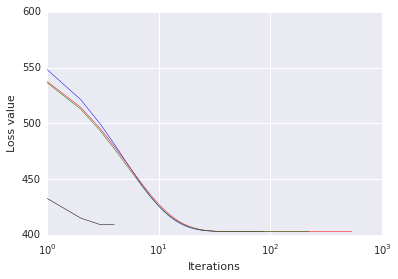

```python
plt.figure()
plt.semilogx(range(len(loss)), loss, "b", lw=0.5) # Batch GD
plt.semilogx(range(len(stoc_loss)),stoc_loss, "r", lw=0.5) # Stochastic GD
plt.semilogx(range(len(mb_loss)),mb_loss, "g", lw=0.5) # Mini-batch GD
plt.semilogx(range(len(loss_dist)),loss_dist, "black", lw=0.5) #Distributed MiniBatch SGD
plt.xlabel("Iterations")
plt.ylabel("Loss value")
plt.show()
```